# Project: Wrangle and Analyze Data

#### Fixing Tidiness Issues

##### Fixing Tidiness Issues 1

###### Define

Joining the prediction value columns p1 to p3 to a combined set of columns.

###### Code

```python
#Splitting the prediction tries into separate dataframes and dropping the other tries.
df_q2_1_temp = df_image_predictions_cleaned.copy()
df_q2_1_temp.rename(columns={'p1':'p','p1_conf':'p_conf', 'p1_dog':'p_dog'}, inplace=True)
columns_to_be_dropped = []
columns_to_be_dropped = ["p2", "p2_conf", "p2_dog", "p3", "p3_conf", "p3_dog"]
df_q2_1_temp.drop(columns_to_be_dropped, axis = 1, inplace=True)
columns_to_be_dropped = []

df_q2_2_temp = df_image_predictions_cleaned.copy()
df_q2_2_temp.rename(columns={'p2':'p','p2_conf':'p_conf', 'p2_dog':'p_dog'}, inplace=True)
columns_to_be_dropped = []
columns_to_be_dropped = ["p1", "p1_conf", "p1_dog", "p3", "p3_conf", "p3_dog"]
df_q2_2_temp.drop(columns_to_be_dropped, axis = 1, inplace=True)
columns_to_be_dropped = []

df_q2_3_temp = df_image_predictions_cleaned.copy()
df_q2_3_temp.rename(columns={'p3':'p','p3_conf':'p_conf', 'p3_dog':'p_dog'}, inplace=True)
columns_to_be_dropped = []
columns_to_be_dropped = ["p1", "p1_conf", "p1_dog", "p2", "p2_conf", "p2_dog"]
df_q2_3_temp.drop(columns_to_be_dropped, axis = 1, inplace=True)
columns_to_be_dropped = []

print(str(df_q2_1_temp.shape)) # Quick check on the validity. --> Looks good.
print(str(df_q2_2_temp.shape))
print(str(df_q2_3_temp.shape))
```

```
(1751, 5)
(1751, 5)
(1751, 5)
```

```python
# Now adding to each temporary data frame a column which states which number of try it is.
df_q2_1_temp['p_try_number'] = 1
df_q2_2_temp['p_try_number'] = 2
df_q2_3_temp['p_try_number'] = 3
```

```python
# Quick check
df_q2_1_temp.sample(3)
```

|  | tweet_id | jpg_url | p | p_conf | p_dog | p_try_number |
| --- | --- | --- | --- | --- | --- | --- |
| 789 | 690597161306841088 | https://pbs.twimg.com/media/CZV-c9NVIAEWtiU.jpg | Lhasa | 0.097500 | True | 1 |
| 564 | 678255464182861824 | https://pbs.twimg.com/media/CWmlvxJU4AEAqaN.jpg | Chihuahua | 0.613819 | True | 1 |
| 523 | 676588346097852417 | https://pbs.twimg.com/media/CWO5gmCUYAAX4WA.jpg | Boston Bull | 0.976577 | True | 1 |

```python
df_q2_2_temp.sample(3) # Quick check
```

|  | tweet_id | jpg_url | p | p_conf | p_dog | p_try_number |
| --- | --- | --- | --- | --- | --- | --- |
| 1618 | 802572683846291456 | https://pbs.twimg.com/media/CyNPmJgXcAECPuB.jpg | Labrador Retriever | 0.173252 | True | 2 |
| 1607 | 800513324630806528 | https://pbs.twimg.com/media/Cxv-nkJUoAAhzMt.jpg | Cardigan | 0.167373 | True | 2 |
| 1422 | 772114945936949249 | https://pbs.twimg.com/media/Crcacf9WgAEcrMh.jpg | Toy Terrier | 0.052980 | True | 2 |

```python
df_q2_3_temp.sample(3) # Quick check
```

|  | tweet_id | jpg_url | p | p_conf | p_dog | p_try_number |
| --- | --- | --- | --- | --- | --- | --- |
| 909 | 700518061187723268 | https://pbs.twimg.com/media/Cbi9dI_UYAAgkyC.jpg | Chihuahua | 0.121839 | True | 3 |
| 947 | 704761120771465216 | https://pbs.twimg.com/media/CcfQgHVWoAAxauy.jpg | Basenji | 0.072097 | True | 3 |
| 1345 | 759159934323924993 | https://pbs.twimg.com/media/CU1zsMSUAAAS0qW.jpg | Soft-Coated Wheaten Terrier | 0.223263 | True | 3 |

```python
# Append the three outcomes/options to one single data frame
df_q2 = df_q2_1_temp.append(df_q2_2_temp)
df_q2 = df_q2.append(df_q2_3_temp)
print(str(df_q2.shape)) # Quick check on the validity. --> Looks good.
print(str(sum(df_q2.duplicated()))) # No duplicates
```

```
(5253, 6)
0
```

```python
df_q2.info()
```

```
<class 'pandas.core.frame.DataFrame'>
Int64Index: 5253 entries, 0 to 2073
Data columns (total 6 columns):
tweet_id        5253 non-null int64
jpg_url         5253 non-null object
p               5253 non-null object
p_conf          5253 non-null float64
p_dog           5253 non-null bool
p_try_number    5253 non-null int64
dtypes: bool(1), float64(1), int64(2), object(2)
memory usage: 251.4+ KB
```

```python
# Handing the temporary, unpivoted, cleaned image prediction table over to the original one.b
df_image_predictions_cleaned = []
df_image_predictions_cleaned = df_q2.copy()
```

###### Test

```python
df_image_predictions_cleaned.info() # Check if the unpivot action has been handed over correctly to the orginal data frame.
```

```
<class 'pandas.core.frame.DataFrame'>
Int64Index: 5253 entries, 0 to 2073
Data columns (total 6 columns):
tweet_id        5253 non-null int64
jpg_url         5253 non-null object
p               5253 non-null object
p_conf          5253 non-null float64
p_dog           5253 non-null bool
p_try_number    5253 non-null int64
dtypes: bool(1), float64(1), int64(2), object(2)
memory usage: 251.4+ KB
```

##### Fixing Tidiness Issues 2

###### Define

Creating one combined table, i.e. merging the three tables by twitter_id.

###### Code

```python
df_twitter_combined = 0
df_twitter_combined = df_twitter_archive_cleaned.copy()
```

```python
# Merging performance data in.
df_twitter_combined = df_twitter_combined.merge(df_tweet_performance, on='tweet_id', how='inner')
```

```python
print("Shape df_twitter_archive_cleaned: " + str(df_twitter_archive_cleaned.shape))
print("Shape df_tweet_performance: " + str(df_tweet_performance.shape))
print("Shape df_twitter_combined: " + str(df_twitter_combined.shape) + " after joining df_twitter_archive_cleaned and df_tweet_performance.")
```

```
Shape df_twitter_archive_cleaned: (2067, 5)
Shape df_tweet_performance: (2340, 3)
Shape df_twitter_combined: (2065, 7) after joining df_twitter_archive_cleaned and df_tweet_performance.
```

```python
# Merging image prediction data in.
df_twitter_combined = df_twitter_combined.merge(df_image_predictions_cleaned, on='tweet_id', how='inner')
```

###### Test

```python
print("Shape df_image_predictions_cleaned: " + str(df_image_predictions_cleaned.shape))
print("Shape df_twitter_combined " + str(df_twitter_combined.shape) + " after joining df_twitter_archive_cleaned, df_tweet_performance and df_image_predictions_cleaned.")
```

```
Shape df_image_predictions_cleaned: (5253, 6)
Shape df_twitter_combined (4935, 12) after joining df_twitter_archive_cleaned, df_tweet_performance and df_image_predictions_cleaned.
```

```python
# Checking the overall shape of the triple-merge.
df_twitter_combined.info()
```

```
<class 'pandas.core.frame.DataFrame'>
Int64Index: 4935 entries, 0 to 4934
Data columns (total 12 columns):
tweet_id          4935 non-null int64
timestamp         4935 non-null object
text              4935 non-null object
expanded_url      4935 non-null object
rating            4935 non-null float64
retweet_count     4935 non-null int64
favorite_count    4935 non-null int64
jpg_url           4935 non-null object
p                 4935 non-null object
p_conf            4935 non-null float64
p_dog             4935 non-null bool
p_try_number      4935 non-null int64
dtypes: bool(1), float64(2), int64(4), object(5)
memory usage: 467.5+ KB
```

The amound of rows and the structure looks good.

## Storing Cleaned Data

```python
# According to the instructions the cleaned data frame of the Twitter archive
# shall be stored to a file called "twitter_archive_master.csv".
df_twitter_archive_cleaned.to_csv("deliverables/twitter_archive_master.csv", header=True, index=False)
```

```python
# The data frame image_prediction_cleaned shall be stored to a separate CSV-file.
df_image_predictions_cleaned.to_csv("deliverables/twitter_image_predictions_master.csv", header=True, index=False)
```

```python
# The data frame tweet_performance shall be stored to a separate CSV-file.
df_tweet_performance.drop_duplicates(inplace=True)
df_tweet_performance.to_csv("deliverables/df_tweet_performance_master.csv", header=True, index=False)
```

```python
# Storing the combined dataset as well to a separate file
df_twitter_combined.to_csv("deliverables/df_twitter_combined_master.csv", header=True, index=False)
```

### Storing Cleaned Data Into A SQLite Database

```python
from sqlalchemy import create_engine
```

```python
# Create SQLAlchemy engine
engine = create_engine('sqlite:///deliverables/twitter_analysis.db')
```

```python
# Storing pandas data frames into the db-tables. In order to keep all processed data in their cleaned and orignal
# versions, the following three subsets are going to be stored next to the final "combined" dataset.
df_twitter_archive_cleaned.to_sql('twitter_archive_master', engine, index=False)
df_image_predictions_cleaned.to_sql('twitter_image_predictions_master', engine, index=False)
df_tweet_performance.to_sql('df_tweet_performance_master', engine, index=False)

# Storing the final master dataset into the database as well. This is the combined version containing the three
# separate sources (joined).
df_twitter_combined.to_sql('df_twitter_combined_master', engine, index=False)
```

## Analysis

Before starting the analysis, I drop all columns except those needed.

```python
columns_to_be_dropped = []
columns_to_be_dropped = ["tweet_id", "timestamp", "text", "expanded_url", "jpg_url"]
df_twitter_combined.drop(columns_to_be_dropped, axis = 1, inplace=True)
columns_to_be_dropped = []
```

The dataset respectively the data frame df_twitter_combined is now ready for analysis.

#### Question 1: What were the 10 highest rated dog breeds on average, according to the prediction with the highest (p1_conf) confidence level?

```python
df_q1 = df_twitter_combined[(df_twitter_combined['p_dog'] == True) &
                           (df_twitter_combined['p_try_number'] == 1)] # p1_conf --> p_try_number = 1
highest_rated_breeds = (df_q1.groupby(['p']).mean()['rating'])
highest_rated_breeds.sort_values(ascending = False).head(10)
```

```
p
Saluki                1.250000
Briard                1.233333
Tibetan Mastiff       1.225000
Border Terrier        1.214286
Silky Terrier         1.200000
Standard Schnauzer    1.200000
Eskimo Dog            1.177778
Gordon Setter         1.175000
Irish Setter          1.175000
Samoyed               1.174359
Name: rating, dtype: float64
```

**Insight:** The highest rated dog breed is the Saluki. Surprisingly, its average rating is 1.25 or 12.5/10. I personally would have expected it to be higher. Furthermore, the distribution of the average ratings per dog breed is close to each other. There is no breed which is rated far better than the rest.

#### Question 2: Which are the top 10 predictated dog breeds in terms of the confidence-level on average?

```python
df_question2 = df_twitter_combined[df_twitter_combined['p_dog'] == True]
```

```python
highest_confidence_breed_prediction = (df_question2.groupby(['p']).mean()['p_conf'])
highest_confidence_breed_prediction.sort_values(ascending = False).head(10)
```

```
p
Bernese Mountain Dog    0.651259
Komondor                0.522381
Samoyed                 0.520342
Pembroke                0.495139
Pug                     0.481903
Blenheim Spaniel        0.475460
Golden Retriever        0.446421
Dalmatian               0.400302
German Shepherd         0.369846
Vizsla                  0.361907
Name: p_conf, dtype: float64
```

**Insight:** The highest average confidence level in predicting the dog breed experienced the Bernese Mountain Dog. The second is the Komondor. Both breeds have a unique appearance, which probably made the prediction easier. The highest confidence level is 65% on average, which should be kept in mind. In my opinion, the level is too low, to really rely on these results. For deeper analysis, you should consider running the images through a model which is either dedicated to dogs only or which is trained better.

#### Question 3: Which dog breeds have the highest average retweet and favorite-count, according to the prediction with the highest (p1_conf) confidence level?

```python
df_q3_1 = df_twitter_combined[(df_twitter_combined['p_dog'] == True) &
                           (df_twitter_combined['p_try_number'] == 1)]
```

```python
# Retweet count
highest_retweet_count = (df_q3_1.groupby(['p']).mean()['retweet_count'])
highest_retweet_count.sort_values(ascending = False).head(10)
```

```
p
Standard Poodle          6284.285714
English Springer         5658.333333
Afghan Hound             5634.666667
Eskimo Dog               5182.500000
Giant Schnauzer          4845.000000
Saluki                   4841.250000
Great Pyrenees           4703.307692
French Bulldog           4606.760000
Lakeland Terrier         4576.866667
Flat-Coated Retriever    4278.375000
Name: retweet_count, dtype: float64
```

```python
# Favorite count
highest_favorite_count = (df_q3_1.groupby(['p']).mean()['favorite_count'])
highest_favorite_count.sort_values(ascending = False).head(10)
```

```
p
Saluki                     23210.250000
French Bulldog             18312.160000
Giant Schnauzer            16554.000000
Afghan Hound               16548.666667
Black-And-Tan Coonhound    16360.000000
Flat-Coated Retriever      16155.000000
Irish Water Spaniel        15702.666667
Standard Poodle            15182.142857
English Springer           15065.333333
Cardigan                   14673.764706
Name: favorite_count, dtype: float64
```

**Insight:** On average the breed Standard Poodle appears to be retweeted most, whereas the Saluki appears to have earned the most favorites by far. However, you can see, that many breeds are in both top ten listings present. This might be a hint of a potential correlation between these variables.

#### Question 4: Does the rating correlate with the number of retweets or favorite-counts?

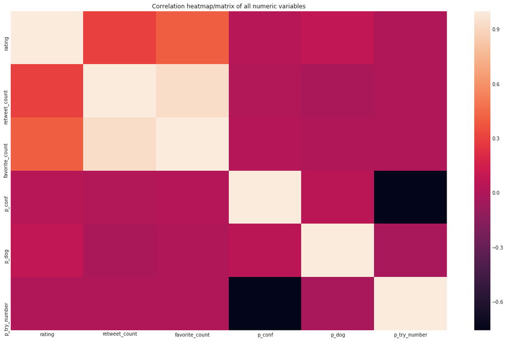

```python
# It makes sense, to create at heatmap showing the correlation factors of all variables first. This serves either to
# answer the question and to potentially discover more interesting relationships between the variables in the dataset.

#Plotting the results of calculations above.
fig = plt.figure(figsize=(20,12))
sns.set_style('whitegrid')

corr = df_twitter_combined.corr()
sns.heatmap(corr,
            xticklabels=corr.columns.values,
            yticklabels=corr.columns.values);
plt.title('Correlation heatmap/matrix of all numeric variables');
```

```python
df_twitter_combined.corr()
```

|  | rating | retweet_count | favorite_count | p_conf | p_dog | p_try_number |
| --- | --- | --- | --- | --- | --- | --- |
| rating | 1.000000 | 0.303094 | 0.405390 | 0.032208 | 0.073449 | 0.000000 |
| retweet_count | 0.303094 | 1.000000 | 0.932059 | 0.012044 | -0.013928 | 0.000000 |
| favorite_count | 0.405390 | 0.932059 | 1.000000 | 0.018496 | 0.002096 | 0.000000 |
| p_conf | 0.032208 | 0.012044 | 0.018496 | 1.000000 | 0.046688 | -0.758019 |
| p_dog | 0.073449 | -0.013928 | 0.002096 | 0.046688 | 1.000000 | -0.024727 |
| p_try_number | 0.000000 | 0.000000 | 0.000000 | -0.758019 | -0.024727 | 1.000000 |

**Insight:** No, the variable rating does neither correlate strongly with the variable retweet_count (0.30), nor with the variable favorite_count (0.41). However, the variable retweet and favorite count correlate strongly with each other (0.93). It appears the viewers of the WeRateDogs Twitter account express their liking using both ways.

#### Question 5: Which items were also visible in the pictures and what are their frequencies?

```python
df_q5 = df_twitter_combined[df_twitter_combined['p_dog'] == False]
df_q5 = (df_q5[['p']].copy())
```

```python
df_q5.p.value_counts(sort=True, normalize=True).head(10) # Showing the relative frequencies.
```

```
Seat Belt      0.066236
Teddy          0.042003
Dingo          0.042003
Siamese Cat    0.037157
Doormat        0.027464
Ice Bear       0.024233
Bath Towel     0.021002
Tennis Ball    0.021002
White Wolf     0.019386
Muzzle         0.019386
Name: p, dtype: float64
```

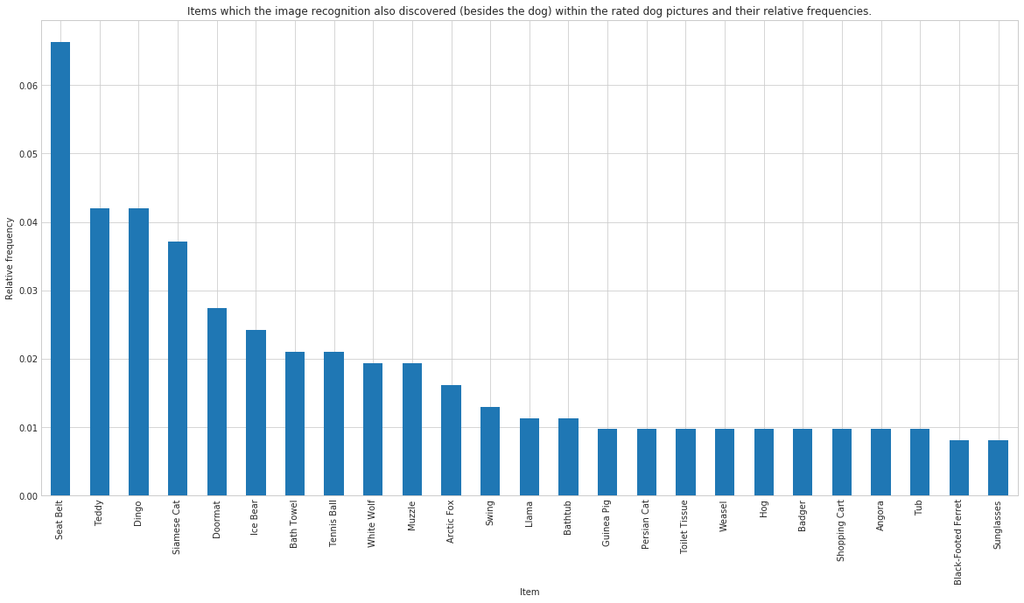

```python
#Plotting results of the calculations above.
fig = plt.figure(figsize=(20,10))
sns.set_style('whitegrid')

df_q5.p.value_counts(sort=True, normalize=True).head(25).plot.bar()
plt.title('Items which the image recognition also discovered (besides the dog) within the rated dog pictures and their relative frequencies.')
plt.xlabel('Item')
plt.ylabel('Relative frequency');
```

**Insight:** The most frequent item within the dog pictures appears to be a "seat belt", followed by teddies. The second item is classified as a Dingo, which actually might come down to a misinterpreted dog breed.

## References

- http://docs.tweepy.org/en/v3.5.0/api.html
- https://stackoverflow.com/questions/12309269/how-do-i-write-json-data-to-a-file
- https://stackabuse.com/reading-and-writing-json-to-a-file-in-python/
- https://stackoverflow.com/questions/27900451/convert-tweepy-status-object-into-json
- https://developer.twitter.com/en/docs/basics/rate-limiting
- https://stackoverflow.com/questions/7370801/measure-time-elapsed-in-python
- https://stackoverflow.com/questions/40705480/python-pandas-remove-everything-after-a-delimiter-in-a-string
- https://stackoverflow.com/questions/42462530/how-to-replace-the-white-space-in-a-string-in-a-pandas-dataframe
- https://stackoverflow.com/questions/39141856/capitalize-first-letter-of-each-word-in-the-column-python
- https://stackoverflow.com/questions/34682828/extracting-specific-selected-columns-to-new-dataframe-as-a-copy
- https://stackoverflow.com/questions/29432629/correlation-matrix-using-pandas